# R, RStudio y forma de trabajar

Pedro J. Pérez (pedro.j.perez@uv.es). Universitat de València

El objetivo de esta sección es proporcionar una breve primera introducción a R y RStudio para personas que no han tenido contacto previo con estos programas y explicitar la forma que tendremos de interactuar con ellos; es decir, la forma de trabajar con ellos (**workflow**).

El curso es una introducción a la Ciencia de Datos: haremos diversos análisis con datos y para ello utilizaremos R. R será el programa que hará los cálculos, gráficos, informes, pero interactuaremos con R, le daremos las ordenes a R, a través de otro programa: RStudio. Así que tendremos que instalar los 2 programas. Por ello, en la [web del curso](https://perezp44.github.io/intro-ds-22-23-web/) tienes un fichero donde se explica como hacerlo: concretamente [aquí](https://perezp44.github.io/intro-ds-22-23-web/mas-recursos/01_instrucciones-instalacion.html).

[Aquí](https://www.dataquest.io/blog/tutorial-getting-started-with-r-and-rstudio/) tienes un articulo que explica, con mucho detalle, como empezar a trabajar con R: instalación, configuración, paquetes, etc…

Se puede trabajar con R/RStudio de varias formas. Nosotros trabajaremos, casi siempre, con `Rprojects`. Enseguida diremos qué son los Rprojects, pero de momento podemos pensar que son carpetas donde se almacenan los ficheros necesarios para hacer un análisis de datos.

Dentro de esas carpetas o `Rprojects` tendremos distintos tipos de ficheros: ficheros de datos, imágenes etc… y unos ficheros, llamados habitualmente **scripts** que contendrán las instrucciones que queramos que sean ejecutadas por R/RStudio. Bien, pues esos scripts o ficheros de ordenes pueden ser de varios tipos. Concretamente, durante el curso utilizaremos 2 tipos de ficheros para darle las ordenes a R:

- `ficheros .R` , y
- `ficheros Rmarkdown` o `ficheros .Rmd`.

Lo normal es que nunca hayas oído hablar de todo esto, así que al principio te sonará complicado, pero en nada te parecerá lo más natural del mundo. Bird by bird!!!

## 1. R

Ya hemos hablado de R, pero …

### ¿Qué es R?

Ya lo habéis visto mientras hacíamos algún ejemplo, pero para los nuevos: R es un lenguaje de programación y un entorno para el análisis estadístico y gráfico. Se puede utilizar para muchas cosas ya que es un lenguaje de programación, pero principalmente se utiliza en el campo de la estadística y la ciencia de datos; de hecho, R fue inicialmente creado en 1993 por dos estadísticos de la Universidad de Auckland: R. Ihaka y R.Gentleman[^1]. A partir de 1997 el desarrollo de R (o **base-R**) es gestionado por un grupo de programadores conocido como “The R-core team”; pero actualmente, el entorno o ecosistema R es el resultado de la colaboración de toda una comunidad de usuarios que extiende las utilidades de base-R mediante la creación de nuevos paquetes y funciones.

R forma parte del sistema GNU y se distribuye bajo la licencia [GNU GPL](https://es.wikipedia.org/wiki/GNU_General_Public_License) por lo que los usuarios tenemos la libertad de usar, estudiar, compartir (copiar) y modificar el software; es decir, R es [**software libre**](https://www.gnu.org/philosophy/free-sw.es.html). Además de software libre, R es gratuito y multiplataforma: está disponible para Windows, Macintosh y GNU/Linux.

La página web oficial de R se llama: [The R Project for Statistical Computing](https://www.r-project.org/). Allí podrás encontrar toda la información y documentación oficial acerca de R. Aunque si alguna vez la necesitas, se puede consultar desde R con la función `help.start()` o, en un formato visualmente más agradable, en [este repositorio](https://colinfay.me/r-manuals/) de Collin Fay un destacado miembro de la actual comunidad R. Si quieres ver las personas que forman parte del R core-team o que han contribuido al desarrollo de R no tienes mas que teclear en R `contributors()`.

R proporciona un amplio abanico de herramientas estadísticas y gráficas (modelos lineales y no lineales, tests estadísticos, análisis de series temporales, algoritmos de clasificación y agrupamiento, etc.). Como R también es un lenguaje de programación, permite que los usuarios lo extiendan definiendo sus propias funciones y paquetes. De hecho, actualmente R se ha convertido de un proyecto colaborativo y abierto en el que sus usuarios pueden publicar paquetes que extienden su configuración básica. Para darte una idea de lo prolífica y colaborativa que es la comunidad R puedes visitar estos 2 proyectos: [R-bloggers](https://www.r-bloggers.com/) y [R-Weekly](https://rweekly.org/). Precisamente estos 2 aspectos (abundancia de paquetes y comunidad de usuarios) son claves en el éxito de R

Ya hemos dicho que R (junto con sus paquetes) puede implementar una gran variedad de técnicas estadísticas y gráficas. Existe un repositorio oficial de paquetes: Comprehensive R Archive Network o [CRAN](https://cran.r-project.org/). CRAN alcanzó los [10.000 paquetes](https://blog.revolutionanalytics.com/2017/01/cran-10000.html) en enero de 2017, y actualmente, julio de 2019, tiene 14.553 paquetes. Además, existen muchos más paquetes en repositorios como [Bioconductor](https://www.bioconductor.org/), [Github](https://github.com/) y otros.

### Instalación de R

Obviamente, para usar R y sus paquetes tenemos que instalarlo primero. Para ello “solo” tienes que ir a [CRAN](https://cran.r-project.org/) y descargar la distribución de R adecuada para tu sistema operativo. Obviamente mejor la última versión. En el momento de re-escribir estas notas la última versión es `R-4.1.1` llamada “Kick Things” released on 2021/08/10.

No te va a a hacer falta pero por si acaso, [aquí](https://jjallaire.shinyapps.io/learnr-tutorial-00-setup/#section-install-r) tienes un vídeo de 1:30 donde se explica de manera sencilla como instalar R.

## 2. RStudio

### ¿Qué es RStudio?

Pues es un programa que utilizaremos para interactuar con R. Las instrucciones que queramos dar a R para que las ejecute se las daremos a través de RStudio. La razón es que la interfaz de usuario (GUI, Graphical User Interface) de R no es muy amigable ni versátil, así que interactuaremos con R a través de RStudio.

RStudio es un programa que nos permitirá interactuar con R de forma más amigable, además de facilitar muchas de las tareas de programación y análisis de datos en R; es decir, RStudio es una GUI (Graphical User Interface). En realidad, RStudio es más que una GUI, es una IDE, un entorno de desarrollo integrado para R, en inglés *‘integrated development environment’* o **IDE**.

El actual científico jefe de RStudio es [Hadley Wickham](http://hadley.nz/). Wickham es uno de los más prolíficos desarrollador de paquetes para R y creador de un nuevo estilo de programar y analizar datos en R conocido como *‘[tidyverse](https://blog.rstudio.org/2016/09/15/tidyverse-1-0-0/)’*. Muchos de los packages que utilizaremos en el curso han sido desarrollados por él y el equipo de RStudio.

### Instalación de RStudio

La versión de escritorio de RStudio también es libre y gratuita. Se puede descargar [aquí](https://www.rstudio.com/products/rstudio/download/). Tienes que descargarte el *‘installer’* adecuado para tu sistema operativo.

Se puede trabajar perfectamente con las opciones por defecto de RStudio, pero os recomiendo cambiar algunas opciones, así que vamos a configurar RStudio.

### Configurando RStudio

Está sección no es obligatoria, solo que es recomendable configurar las opciones de RStudio. ¿Cómo? En RStudio, sigue está ruta de menús: `Tools > Global OPtions...`

[figure not shown]

Se abrirá una ventana (que puedes ver abajo) con las opciones de configuración de RStudio. De momento vamos sólo a tocar la categoría que ves en la imagen; es decir, `R General`. Tienes que hacer dos cosas:

1. desmarcar todas las casillas (quitarles los ticks)
2. Es importante, poner `Never` en la casilla donde pone “Save workspace to .RData on exit”.

Al final, en mi ordenador, la ventana con las opciones de `R General` queda como:

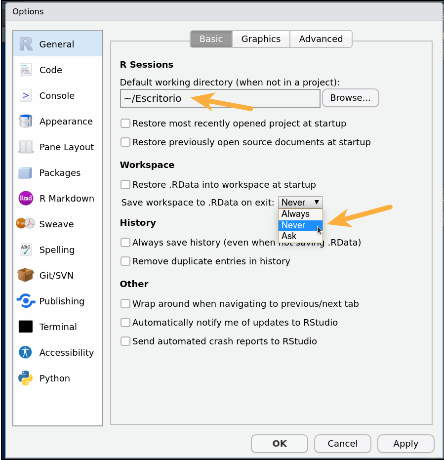

En tu ordenador debe quedar todo igual excepto la caja de texto. El texto de la caja le dice a RStudio donde se guardarán los archivos que vayamos generando; es decir, indica el directorio de trabajo por defecto. Como mi sistema operaivo es Linux y habitualmente trabajo en el escritorio de mi PC, en la imagen de abajo pone “~/Escritorio”, si mi sistema operativo fuese Windows pondría algo como “C:/Users/perezp/Desktop”. Te recomiendo trabajar sobre el escritorio o Desktop, pero puedes seleccionar la carpeta en la que más cómoda trabajes[^2].

[figure not shown]

Ya explicaré en clase porqué seleccionamos estas opciones en RStudio.

#### Aún más configuración de RStudio

1. En RStudio sigue está ruta de menús: `Tools > Global OPtions...` y selecciona `Code`. Intenta dejar la opciones de la pestaña `Editing` como ves en la imagen de abajo. Concretamente lo que más me interesa es que esté marcada la opción `Insert spaces for tab`

[figure not shown]

2. En RStudio sigue está ruta de menús: `Tools > Global OPtions...` y selecciona `Code`. Ahora intenta dejar las opciones de la pestaña `Saving` como ves en la imagen de abajo. Lo más importante es que en la caja de texto `Default text encoding` ponga: `UTF-8`. Esto evitará que tengamos problemas con la codificación de loa caracteres, por ejemplo con la eñe o con las tildes.

[figure not shown]

Ya tenemos R y RStudio instalados y configurados, así que vamos a empezar a toquetear RStudio.

### Conociendo la interfaz de RStudio

Durante el curso vamos a utilizar R para hacer análisis estadísticos pero lo vamos a hacer a través de RStudio, así que el primer paso es familiarizarnos un poco con la interfaz de RStudio. Para acostumbrase a R y RStudio lo mejor es la práctica, pero si os hiciese falta, [aquí](https://ismayc.github.io/rbasics-book/index.html) tenéis un fantástico libro para habituarse a trabajar con R y RStudio.

Al abrir RStudio verás que al principio tiene 3 paneles, aunque enseguida abriremos un cuarto panel. La consola es el panel de la izquierda. Cuando tengamos 4 paneles la consola será el panel situado izquierda-abajo. Podemos pensar que la consola es lo más parecido a R, ya que en la consola se pueden ejecutar instrucciones de R directamente.

Cuando abras RStudio veras lo siguiente:

[figure not shown]

- Consola (izquierda)
- Environment/History (arriba-derecha)
- Files/Plots/Packages/Help (abajo-derecha)

Ya sabemos que el panel de la izquierda es la consola. En la consola se ve un mensaje de bienvenida que nos dice que versión de R estamos usando y alguna cosa más. Al final del texto aparece el símbolo `>`. A este símbolo se le conoce como *prompt* y simplemente nos indica que el intérprete de R, que R, está listo para ejecutar nuestras instrucciones.

¿Cómo le damos las instrucciones u ordenes a R? La forma más inmediata es escribiendo las ordenes en la consola, después del prompt (`>`). Por ejemplo, si escribimos en la consola `2+2` y presionamos `Enter`, R ejecutará la instrucción y nos devolverá el resultado.

A veces usaremos la consola para ejecutar alguna instrucción, pero en general ejecutaremos las instrucciones a través de un “script”. Una razón para no usar la consola es que trabajar en la consola es muy limitado ya que las instrucciones se han de introducir una a una. Otra razón es que queremos tener un registro con todas las instrucciones que ejecutemos para poder replicar nuestro análisis en otro momento; así que lo habitual es trabajar con **scripts** o **ficheros de instrucciones**.

Un script no es más que un fichero de texto con extensión `.R` en el que escribiremos las instrucciones que queramos que R ejecute.

Vamos a crear nuestro primer script. Para ello tienes que seguir esta ruta de menús en RStudio: `File > New File > R Script`. Visualmente:

[figure not shown]

Cuando pinches con el ratón en `R Script` se abrirá en RStudio un nuevo panel, el cuarto, arriba a la izquierda. Visualmente:

[figure not shown]

Este cuarto panel (arriba-izquierda) en realidad es un editor de texto. En él podemos escribir las instrucciones que queramos que ejecute R. Por ejemplo, fíjate en la siguiente imagen lo que he escrito en el panel arriba-izquierda:

[figure not shown]

He escrito estas cuatro lineas:

```r
# mi primer script de R
2 + 2
5 * 6
400/2
```

Escribe tú también (o copia y pega) estás cuatro lineas de texto en el editor (arriba-izquierda) de tu Rstudio.

R ejecutará, cuando se lo indiquemos, las lineas de instrucciones una a una.

Una vez hayas escrito o pegado esas 4 lineas en RStudio, verás que la primera linea es diferente: lo más evidente es que está en color verde, pero en realidad lo importante es que comienza con el símbolo `#`. Este hecho, está marcando/diciendo a R que esa linea es un comentario para los humanos, para nosotros, no es código R y por tanto R no la ejecutará.

En un script sólo se pueden escribir 2 cosas:

- comentarios (si la linea comienza con `#`). R no las ejecutará
- instrucciones R (no comienzan con `#`). R las ejecutará si están escritas en R; es decir, si siguen las reglas del lenguaje R. Si están mal escritas R nos devolverá un mensaje de error. Tenemos que aprender R ya!!!

Hemos escrito cuatro lineas en nuestro script y ahora queremos que R las ejecute. R ejecutará, cuando se lo indiquemos, las lineas de instrucciones una a una.

Para ejecutar una linea, situamos el cursor en ella y pulsamos `Crtl` + `Enter`.

Please, sitúa el cursor en la primera linea y pulsa `Crtl` + `Enter`. Observa qué ha ocurrido. Le hemos dicho a R que ejecute la primera linea, pero como esta primera linea comienza con `#`, R la ha interpretado (correctamente) como un comentario y, por supuesto, no la ha ejecutado, por lo que ha pasado a la segunda linea, y esta vez sí que la ejecuta. Como la segunda linea no comienza con `#`, R la interpreta como una instrucción de R y, sí la entiende (si las has escrito correctamente siguiendo la sintaxis o lenguaje de R), ejecutará la instrucción. R entiende que significa `2 + 2`, así que ejecuta la instrucción y nos devuelve el resultado en la consola.

En la imagen de abajo yo ya he ejecutado la instrucción `2 + 2`. R nos muestra el resultado en la consola: primero nos muestra, en azul, la instrucción que ha ejecutado; es decir `> 2 + 2` y luego nos nos muestra, en negro, el resultado de la ejecución de la instrucción; es decir `[1] 4`. Ya veremos que significa el [1] de la linea de resultados.

[figure not shown]

Es más fácil hacerlo que contarlo, aunque puede que te atasques en alguna cosa, normal!!. Por ejemplo, si en lugar de poner el cursor en la segunda linea, señalas o subrayas solo parte de la linea, entonces, seguramente R no te entenderá. Ahora te toca a ti: please, ejecuta la tercera linea de tu script.

¿Cómo le decimos a R que ejecute la tercera linea `5 * 6`? Cuando lo hacíamos en la consola simplemente había que pulsar `Enter`, pero ahora estamos trabajando en un script: hay que situar el cursor en la linea que queremos ejecutar y darle a `Crtl` + `Enter`. R ejecutará la instrucción y nos devolverá el resultado en la consola.

Enseguida aprenderemos más instrucciones o funciones de R, ahora solo estamos intentando familiarizándonos con el interfaz de RStudio. Ya sabemos como crear un fichero con instrucciones de R (ó script) y como ejecutar esas instrucciones.

Lo normal es que guardes tus scripts en un archivo por si tuvieses que volver a correr las mismas instrucciones más adelante. Para guardar tus instrucciones en un fichero sólo tienes que seguir esta ruta de menús en RStudio: `File > Save as ...`

Tendrás que elegir un nombre para tu script y decidir en que carpeta de tu ordenador guardarlo. Si decides que tu script se llame `my_script_01`, se creará un fichero (donde tú hayas decidido) llamado `my_script_01.R`. Fíjate que la extensión del archivo es **`.R`**, está extensión identifica los scripts o ficheros con instrucciones de R.

Esto vas a acabar entendiéndolo en poco tiempo, pero cuanto antes lo entiendas mejor: damos las ordenes/instrucciones a R por escrito, generalmente usamos “scripts”; es decir, escribimos las instrucciones en un fichero con extensión .R. Para ejecutar las ordenes que hemos escrito en nuestro fichero R hemos de, linea por linea, teclear: `Crtl` + `Enter`. Si la orden tiene sentido, es decir, si R entiende la orden, la ejecutará y te mostrará el resultado en la Consola.

Bien, ya sabemos hacer que R ejecute nuestras instrucciones: podemos ejecutar ordenes en la Consola (con `Enter`) o en un script (`Crtl` + `Enter`). Usaremos la consola a veces, muchas veces trabajaremos con scripts o ficheros .R pero, poco a poco, acabaremos trabajando de otra forma.

Como queremos que nuestros análisis sean reproducibles, habitualmente trabajaremos con `Rprojects` y con `ficheros .Rmd`. **Sí!!**, en lugar de con `ficheros .R` (o scripts) trabajaremos con `ficheros **Rmarkdown**` ó `ficheros .Rmd`. Ya lo veremos, pero antes tendremos que familiarizarnos un poco más con el lenguaje R. De momento seguimos con el interfaz de RStudio.

#### Los 4 paneles de RStudio

Vamos a mirar con un poco más de detalle **los 4 paneles de RStudio**. Como puedes ver en la imagen de abajo, generalmente, a la izquierda encontramos la consola y el editor de scripts. Ya sabemos que desde estos dos paneles podemos dar instrucciones a R para que las ejecute.

[figure not shown]